# Homework 6

Caden Zonnefeld

15 April 2020

## Question 1

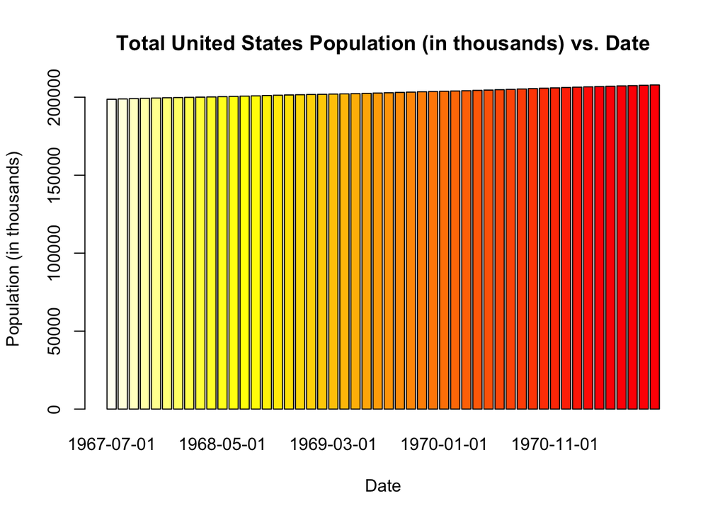

```r
library(ggplot2)
economicsSubset <- economics[1:50,]
barplot(economicsSubset$pop~economicsSubset$date, col=heat.colors(50,rev=T), xlab="Date", ylab="Population (in thousands)", main="Total United States Population (in thousands) vs. Date")
```

I collected a subset of the US economics time series dataset and used a sequential pallette to color the comparison between population (in thousands) and date. Based on the sequential pallette we can see that lighter colors correspond to a smaller total population while darker colors correspond to a larger total population.

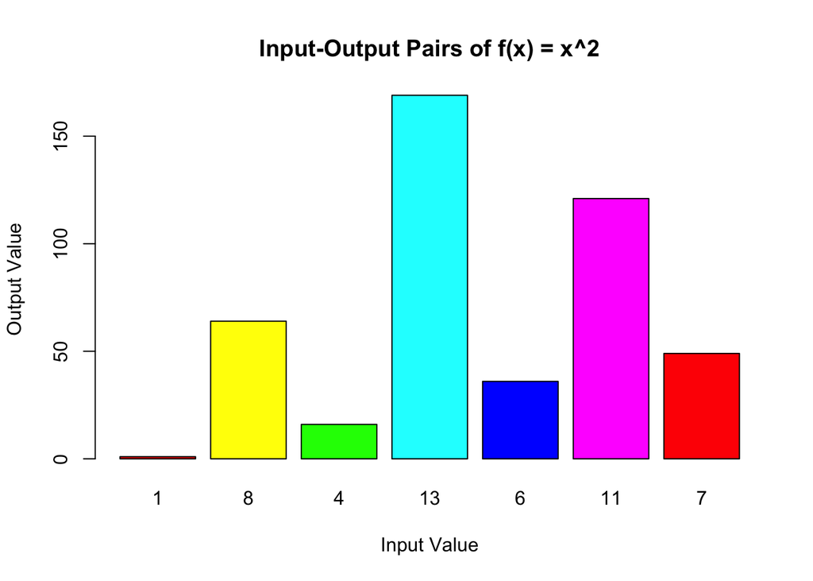

```r
x <- c(1,8,4,13,6,11,7)
y <- c(1,64,16,169,36,121,49)
df <- data.frame(x,y)
df$x <- factor(df$x, levels = df$x)
barplot(y~x,data=df,col=rainbow(6), xlab = "Input Value", ylab="Output Value",main="Input-Output Pairs of f(x) = x^2")
```

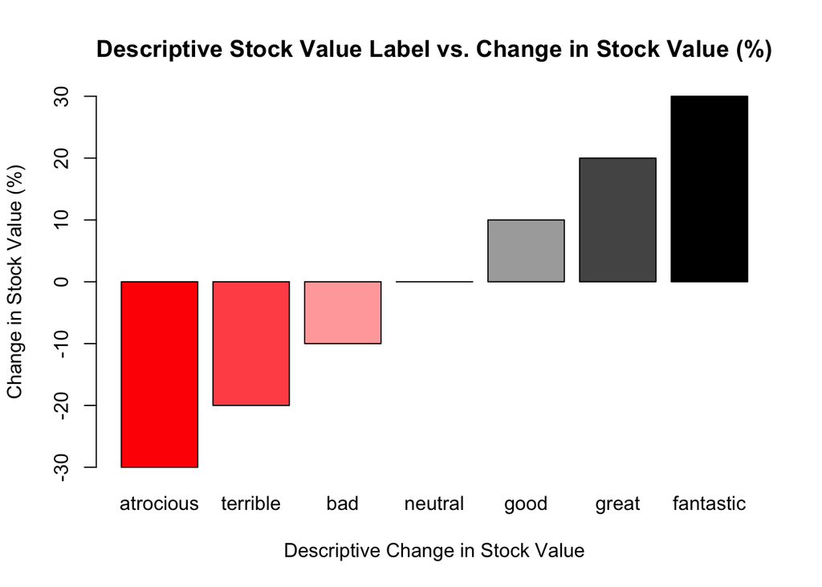

```r
rwb <- colorRampPalette(c("red","white","black"))
stocks <- data.frame(descriptive=c("atrocious","terrible","bad","neutral","good","great","fantastic"),
                     rating=c(-30,-20,-10,0,10,20,30))
stocks$descriptive <- factor(stocks$descriptive,levels=stocks$descriptive)
barplot(rating~descriptive,data=stocks,col=rwb(7), ylab="Change in Stock Value (%)", xlab="Descriptive Change in Stock Value", main="Descriptive Stock Value Label vs. Change in Stock Value (%)")
```

I used a divergent pallette to color a barplot that detailing change in stock value. The neutral line of no change is 0% and is white. The darker the color black the larger the increase in stock value percentagewise; conversely, the darker the color red the larger the decrease in stock value percentagewise. This captures the divergent color pallette becoming either darker black or darker red.

## Question 2

In the situation of my previous example using stock growth or decay, it would be confusing to assign the color black to a decrease in value and red to an increase in value. This is because company profits (stock profits) are conventionally referred to as those “in the black” and companies losses (stock losses) are conventionally referred to as “in the red.” Switching the order of colors may confuse or mislead the audience.

## Question 4

Relative scaling can be used to highlight the numeric amount of change from column to column in a bar chart. In general, relative scaling puts a spotlight on the numeric amount of change from osbervation to observation (or column to column/data point to data point). Conversely, absolute scaling better identifies the proportional change frome column to column in a bar chart. In general, absolute scaling does a better job of giving an intuitive/visual sense of the proportional change from observation to observation (or column to column/data point to data point).

## Question 5

```r
svg("barplot.svg",width=6,height=4)
barplot(y~x,data=df,col=rainbow(6), xlab = "Input Value", ylab="Output Value",main="Input-Output Pairs of f(x) = x^2")
dev.off()
```

The above code demonstrates how to save a graphic into a SVG file, I saved the barplot for the equation f(x)=x^2 that I used for an example in the first question. A SVG or Stable Graphics File is an image format geared toward markdown languages and equipped with support for animation and interactivity.

```r
png("barplot.png",units="in",width=6,height=4,res=72)
barplot(y~x,data=df,col=rainbow(6), xlab = "Input Value", ylab="Output Value",main="Input-Output Pairs of f(x) = x^2")
dev.off()
```

The above code demonstrates how to save a graphic into a PNG file, I saved the barplot for the equation f(x)=x^2 that I used for an example in the first question. A PNG or Portable Network Graphics file is a common image format. PNG files are compatible with pallette-based, RGB, and greyscale graphics.A given PNG file consists of one image with chunks that are encoded and compressed.

## Question 6

The color pair that colorblind people have a particularly difficult time distinguishing is red and green. Other less prevalent color pairs that are difficult for colorblind people to distinguish are (green and brown), (blue and purple), and (light green and yellow).

## Question 7

Another way to add information in a graph is by utilizing different shading techniques according to each variable. For example “low” quality could correspond to horzontal stripes, “mediocre” quality could correspond to vertical stripes, and “high” quality could correspond to diagonal stripes. However, this technique would be contingent upon not using white as a color selection (for white backgrounds that is).